# Describing and Exploring the Fatality of Aviation Accidents from 2008 to 2020

For an overview of the summary statistics of all categorical variables per type of aircraft and a histogram of the continuous variable Fatalities, see Table 1 and Figure 1 below.

```r
data %>%
  ## Through CreateTableOne, we create a table that includes these variables
  CreateTableOne(vars = c("FlightPhase", "InjuryLevel","Engines",
                          "Year", "EngineType",
                          "WeightCat"),
                 ## we want all variables to be stratified by type of aircraft
                 strata = "AircraftType",
                 ## and we want engines and year to be noted as factor variables
                 factorVars = c("Engines", "Year"), data =  .,
                 ## it should not perform a t-test
                 test = FALSE) %>%
  ## Styling done thorugh kableone and the package KableExtra
  kableone(., format = "html",
    caption =
    c("Table 1. Summary statistics for included variables per type of aircaft")) %>%
  kable_minimal(full_width = TRUE) %>%
  row_spec(c(1,2, 14, 15, 21, 27, 43, 48), bold = T, background = "lightgray") %>%
  column_spec(c(2:3), background = "white")
```

Table 1. Summary statistics for included variables per type of aircaft

|  | Airplane | Helicopter |
| --- | --- | --- |
| n | 5696 | 413 |
| FlightPhase (%) |  |  |
| Unknown | 1078 (18.9) | 46 (11.1) |
| Approach | 510 ( 9.0) | 30 ( 7.3) |
| En route | 803 (14.1) | 147 (35.6) |
| Initial Climb | 66 ( 1.2) | 0 ( 0.0) |
| Landing | 1723 (30.2) | 56 (13.6) |
| Manoeuvring | 296 ( 5.2) | 74 (17.9) |
| Post-impact | 0 ( 0.0) | 1 ( 0.2) |
| Standing | 204 ( 3.6) | 13 ( 3.1) |
| Take-off | 713 (12.5) | 39 ( 9.4) |
| Taxi | 302 ( 5.3) | 7 ( 1.7) |
| Tow | 1 ( 0.0) | 0 ( 0.0) |
| InjuryLevel (%) |  |  |
| Unknown | 2071 (36.4) | 21 ( 5.1) |
| Fatal | 1012 (17.8) | 171 (41.4) |
| Minor | 312 ( 5.5) | 32 ( 7.7) |
| None | 1888 (33.1) | 150 (36.3) |
| Serious | 413 ( 7.3) | 39 ( 9.4) |
| Engines (%) |  |  |
| 1 | 1864 (32.7) | 224 (54.2) |
| 2 | 3513 (61.7) | 189 (45.8) |
| 3 | 57 ( 1.0) | 0 ( 0.0) |
| 4 | 258 ( 4.5) | 0 ( 0.0) |
| 6 | 4 ( 0.1) | 0 ( 0.0) |
| Year (%) |  |  |
| 2008 | 679 (11.9) | 53 (12.8) |
| 2009 | 495 ( 8.7) | 60 (14.5) |
| 2010 | 840 (14.7) | 92 (22.3) |
| 2011 | 663 (11.6) | 83 (20.1) |
| 2012 | 260 ( 4.6) | 14 ( 3.4) |
| 2013 | 311 ( 5.5) | 23 ( 5.6) |
| 2014 | 363 ( 6.4) | 23 ( 5.6) |
| 2015 | 279 ( 4.9) | 29 ( 7.0) |
| 2016 | 400 ( 7.0) | 33 ( 8.0) |
| 2017 | 335 ( 5.9) | 3 ( 0.7) |
| 2018 | 334 ( 5.9) | 0 ( 0.0) |
| 2019 | 336 ( 5.9) | 0 ( 0.0) |
| 2020 | 188 ( 3.3) | 0 ( 0.0) |
| 2021 | 169 ( 3.0) | 0 ( 0.0) |
| 2022 | 44 ( 0.8) | 0 ( 0.0) |
| EngineType (%) |  |  |
| Electric | 3 ( 0.1) | 0 ( 0.0) |
| Jet | 2574 (45.2) | 0 ( 0.0) |
| Piston | 1606 (28.2) | 60 (14.5) |
| Turboprop | 1513 (26.6) | 353 (85.5) |
| WeightCat (%) |  |  |
| <2250 | 643 (11.3) | 50 (12.1) |
| >5700 | 3088 (54.2) | 78 (18.9) |
| 2250-5700 | 1941 (34.1) | 285 (69.0) |
| Unknown | 24 ( 0.4) | 0 ( 0.0) |

The distribution of number of fatalities was very skewed and consisted of 62% zeros (see Table 2), indicating no deaths during the accident. Additionally there was a large proportion (19%) of missing values. Among the fatal accidents, the number of deaths were most frequently between 1 and 25 (Figure 1) with median = 2. However, there are many individual accidents with the number of victims ranging from 25 to 300.

```r
#proportion of 0 fatalities and missing values
data %>%
  subset(Fatalities==0 | is.na(data$Fatalities)) %>%
  mutate(Fatalities= case_when(Fatalities==0 ~ "0",
                               is.na(Fatalities)~ "Missing"
                               )) %>%
  group_by(Fatalities) %>%
  summarize(n = n(),
            prop= round(n/nrow(data), digits=2))%>%
  kableone(., format = "html",
    caption =
    c("Table 2. Number of fatalities: proportion of 0 and missing values"))
```

Table 2. Number of fatalities: proportion of 0 and missing values

| Fatalities | n | prop |
| --- | --- | --- |
| 0 | 3770 | 0.62 |
| Missing | 1141 | 0.19 |

```r
#median of fatalities for fatal accidents
medFatalities<-median(data$Fatalities[data$Fatalities!=0 & !is.na(data$Fatalities)])
```

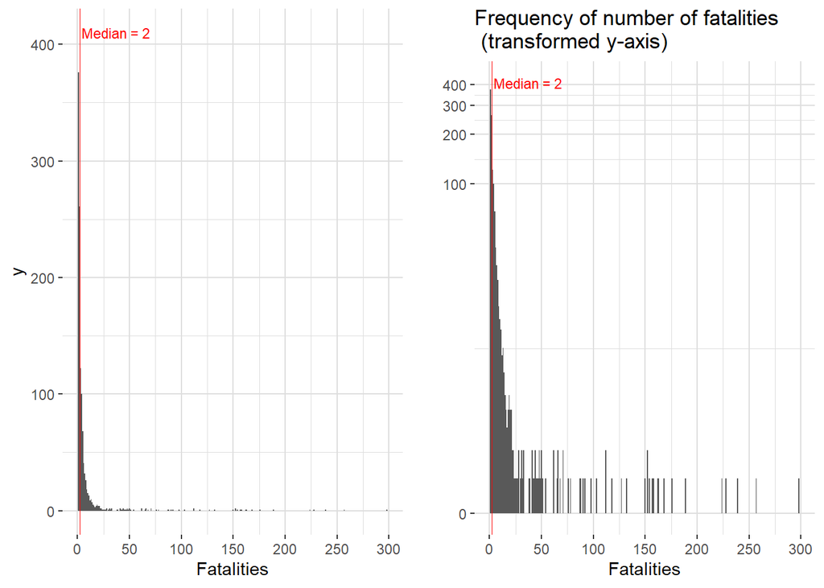

Figure 1

```r
#frequency of number of victims among fatal accidents
#"raw" histogram
fat.notrans<-data %>%
  subset(Fatalities!=0 & !is.na(data$Fatalities)) %>%
  ggplot(aes(Fatalities))+
  geom_histogram(binwidth = 1)+
  scale_y_continuous(breaks=seq(0,400, by=100))+
  my_theme1+
  geom_vline(xintercept = medFatalities,
             color="red", size=0.3)+
  annotate("text", x=medFatalities+35, y=410, label=paste("Median =",medFatalities), color="red", size = 3)+
  scale_x_continuous(breaks=seq(0, 300, by=50))

#histogram with transformed y-axis to detect smaller counts
fat.trans<-data %>%
  subset(Fatalities!=0 & !is.na(data$Fatalities)) %>%
  ggplot(aes(Fatalities))+
  geom_histogram(binwidth = 1) +
  scale_y_continuous(trans = "pseudo_log", breaks=seq(0,400, by=100))+
  my_theme1+
  labs(title="Frequency of number of fatalities \n (transformed y-axis)", y="")+
  geom_vline(xintercept = medFatalities,
             color="red", size=0.3)+
  annotate("text", x=medFatalities+35, y=410, label=paste("Median =",medFatalities), color="red", size = 3)+
  scale_x_continuous(breaks=seq(0, 300, by=50))

ggarrange(fat.notrans, fat.trans)
```

## Chapter 2: Exploratory data analysis

For our exploratory data analysis, we wanted to investigate the following three questions:

1. Does the number of accidents seem to change over time?
2. During which flight phase do the most accidents seem to occur?
3. What are the risk types associated with fatal and non-fatal accidents?

### 2.1: Accidents over time

To investigate the number of accidents over time, we created the following plots that show the amount of accidents over time per type of aircraft in different parameterizations of accident: (a) total death count, (b) accident count and (c) fatal accident count.

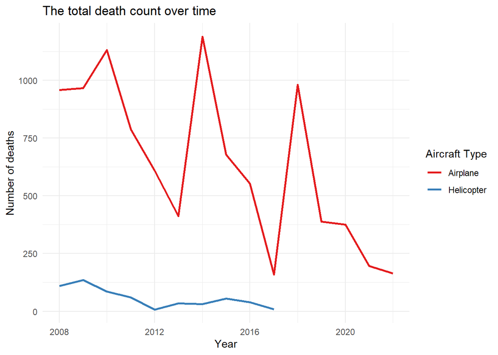

Figure 2

```r
#death count per year- trend
data %>% filter(Fatalities >0) %>% group_by(Year,AircraftType) %>%
  summarise(sum=sum(Fatalities)) %>% ggplot(aes(x=Year, y=sum,color=AircraftType)) +
  geom_line(size=1)  + scale_color_brewer(palette="Set1")+
  labs(x = "Year", y="Number of deaths",color="Aircraft Type")+ ggtitle("The total death count over time")+theme_minimal()
```

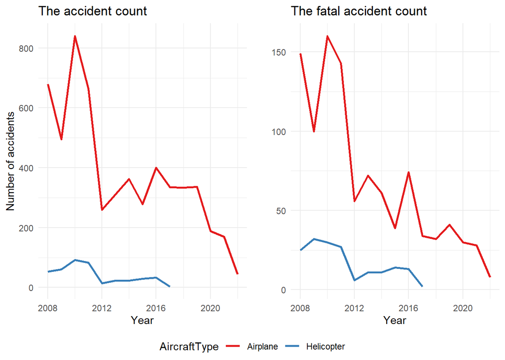

Figure 3

```r
#number of accidents per year - trend
a<-data %>% group_by(Year,AircraftType) %>%
  summarise(count=n()) %>% ggplot(aes(x=Year, y=count,color=AircraftType)) +
  geom_line(size=1) +  scale_color_brewer(palette="Set1")+ggtitle("The accident count")+
  labs(x = "Year", y="Number of accidents")+theme_minimal()

#The fatal accidents per year-trend
c<-data %>% filter(Fatalities >0) %>% group_by(Year,AircraftType) %>%
  summarise(count=n()) %>% ggplot(aes(x=Year, y=count,color=AircraftType)) +
  geom_line(size=1) +scale_color_brewer(palette="Set1")+
  labs(x = "Year", y="")+ ggtitle("The fatal accident count")+theme_minimal()
ggarrange(a,c, common.legend = TRUE,legend = "bottom")
```

Figure 3 shows a large drop in the number of accidents after 2010. Hence, we wished to explore what might have caused this drop.

#### 2.1.1: Investigation of the drop between 2010 and 2012

What might have caused the drop in the number of accidents after 2010? We explored whether any of the other variables in the dataset might be able to explain the drop in the number of accidents through visual inspection of the plots below.

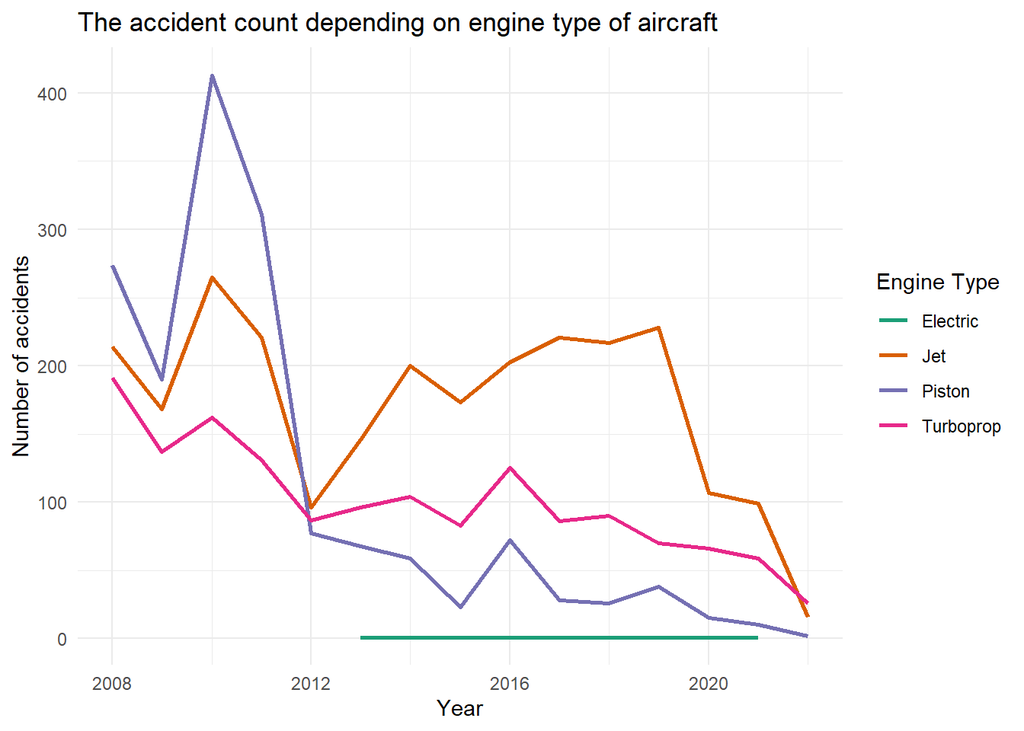

Figure 4

```r
data %>%subset(AircraftType=="Airplane" ) %>% group_by(Year,EngineType) %>%
  summarise(count=n()) %>% ggplot(aes(x=Year, y=count,color=EngineType)) +
  geom_line(size=1) +scale_color_brewer(palette="Dark2")+
  labs(x = "Year", y="Number of accidents",color="Engine Type")+
  ggtitle("The accident count depending on engine type of aircraft")+
  theme_minimal()
```

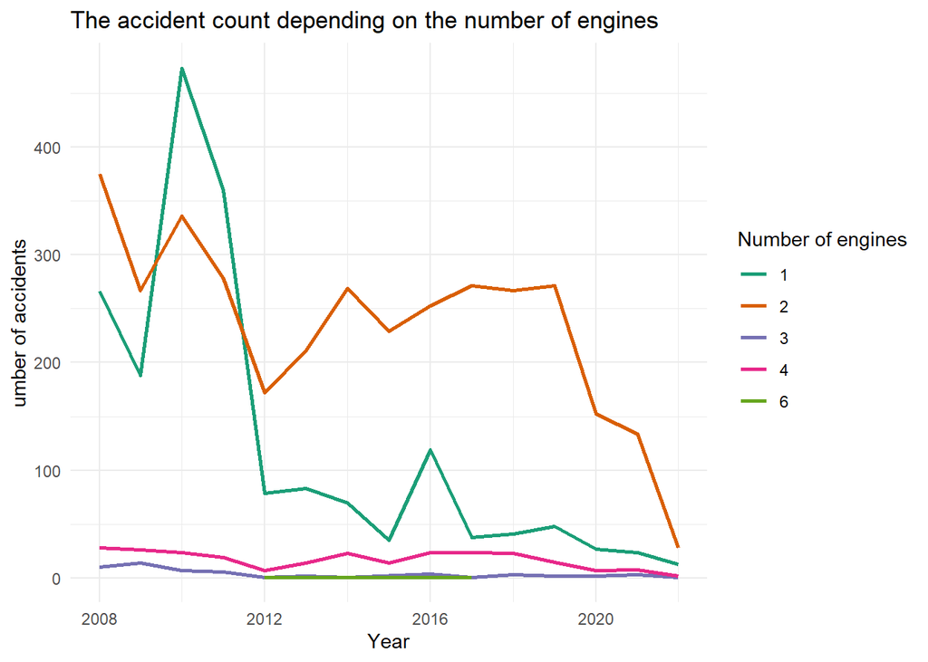

Figure 5

```r
data %>%subset(AircraftType=="Airplane" ) %>% group_by(Year,Engines) %>%
  summarise(count=n()) %>% ggplot(aes(x=Year, y=count,color=as.factor(Engines))) +
  geom_line(size=1) +scale_color_brewer(palette="Dark2")+
  labs(x = "Year", y="umber of accidents",color="Number of engines")+
  ggtitle("The accident count depending on the number of engines")+
  theme_minimal()
```

Figure 4 shows that for the type of engine, piston-type engines had the largest difference in the amount of accidents between 2010 and 2012. As for the number of engines, we find that single engine machines had the largest difference in the amount of accidents between 2010 and 2012 (see Figure 5).

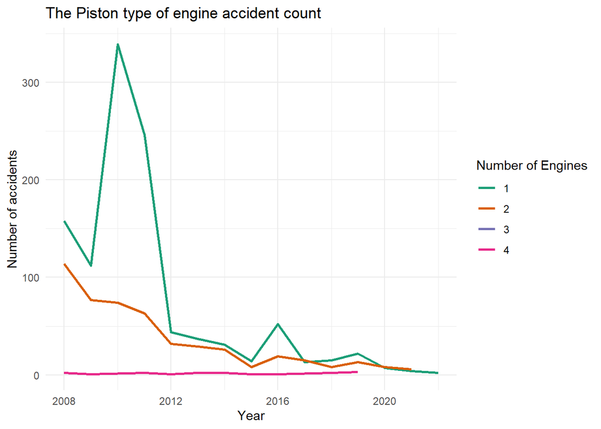

Figure 6

```r
#filter AircraftType and Piston engine type specifically
data %>%filter(AircraftType=="Airplane" , EngineType=="Piston") %>%
  group_by(Year,Engines) %>%
  summarise(count=n()) %>%
  ggplot(aes(x=Year, y=count,color=as.factor(Engines))) +
  geom_line(size=1) +scale_color_brewer(palette="Dark2")+
  labs(x = "Year", y="Number of accidents",color="Number of Engines")+
  ggtitle("The Piston type of engine accident count")+
  theme_minimal()
```

Combining the two plots in Figure 6, we indeed find that the largest difference in the amount of accidents is in single-piston engines. This could be indicative of perhaps an interaction effect between engine-type and number of engines on the number of accidents.

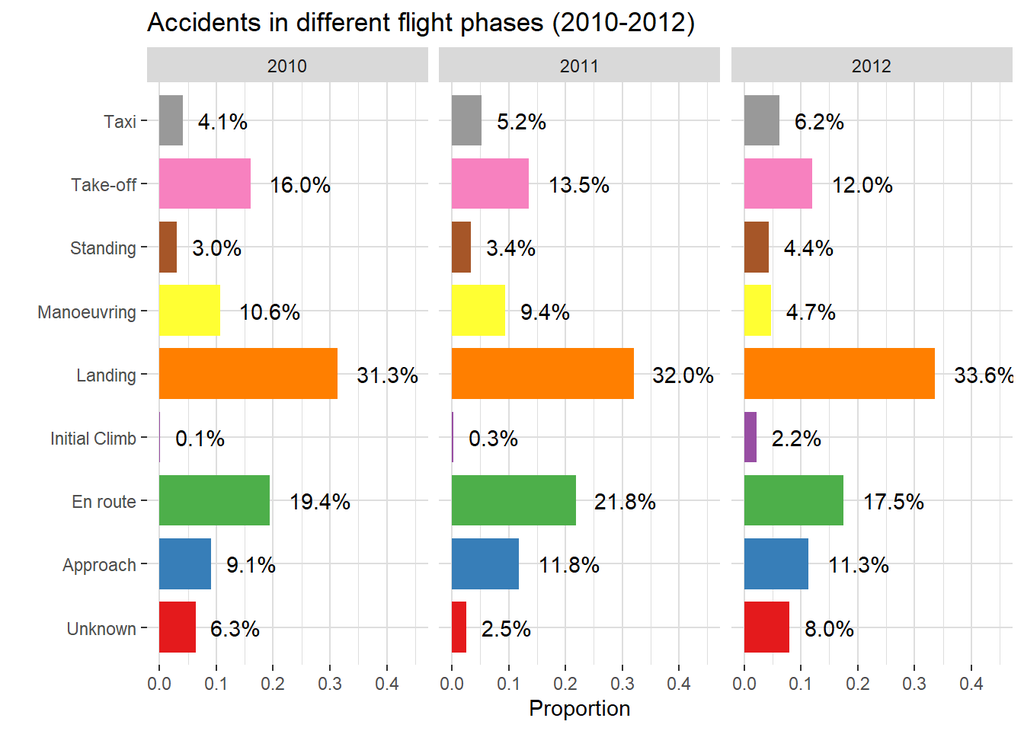

Figure 7

```r
data %>% subset(Year %in% c("2010","2011","2012")) %>%
  ggplot(aes(x=FlightPhase, group=Year))+
  geom_bar(aes(y = ..prop.., fill = factor(..x..)), stat="count",width=0.8)+
  geom_text(aes( label = scales::percent(..prop..,accuracy = 0.1),
                   y= ..prop.. ), stat= "count", hjust = -0.3)+
  coord_flip()+my_theme1+
  ylim(c(0,0.45))+scale_fill_brewer(palette="Set1")+ facet_wrap(~Year)+ylab("Proportion")+xlab("")+
  ggtitle("Accidents in different flight phases (2010-2012)")
```

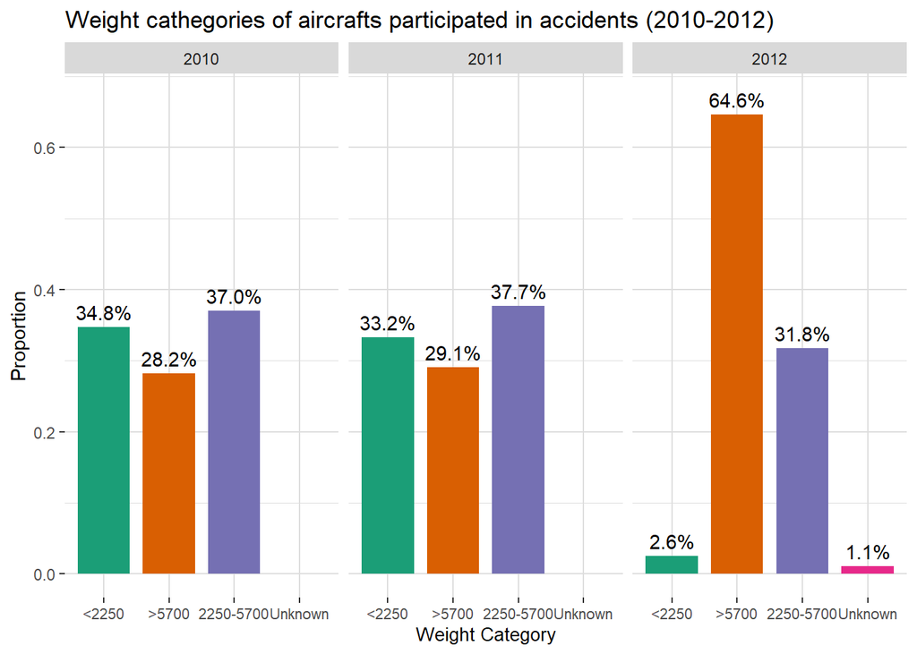

Figure 8

```r
data %>% subset(Year %in% c("2010","2011","2012")) %>%
  ggplot(aes(x=WeightCat, group=Year))+geom_bar(aes(y = ..prop..,
                                                    fill = factor(..x..)),
                                                stat="count",width=0.8)+
  ylim(c(0,0.67))+
  geom_text(aes( label = scales::percent(..prop..,accuracy = 0.1),
                   y= ..prop.. ), stat= "count", vjust = -.5) +my_theme1+
        theme(axis.text.x = element_text(size = 8.4),
        axis.title.x = element_text(size=10))+scale_fill_brewer(palette="Dark2")+
  facet_wrap(~Year)+ylab("Proportion")+xlab("Weight Category")+
  ggtitle("Weight cathegories of aircrafts participated in accidents (2010-2012)")
```

Figure 7 and 8 look at the relation between flightphase and weight categories respectively and the proportion of accidents per year. Figure 7 shows that the proportion of accidents per flightphase are quite consistent over the years. The latter plot, however, does show that in 2012, there was a much lower proportion of accidents in the lowest weight category, and a much higher proportion of accidents in the highest weight category compared to 2010 and 2011. This could be indicative that there were less issues with lower weight aircrafts and thus fewer accidents. However, important to note is that this could also be confounded by the number of flights per aircraft. Confirmatory research would be necessary for proper conclusions.

### 2.2: Exploring fatality

#### 2.2.1: How frequent are fatal accidents compared to the other Injury Level categories?

To investigate the fatality of aircraft accidents, we made the following plot (see Figure 9) which shows that one fifth of all aircraft accidents result in a fatal injury.

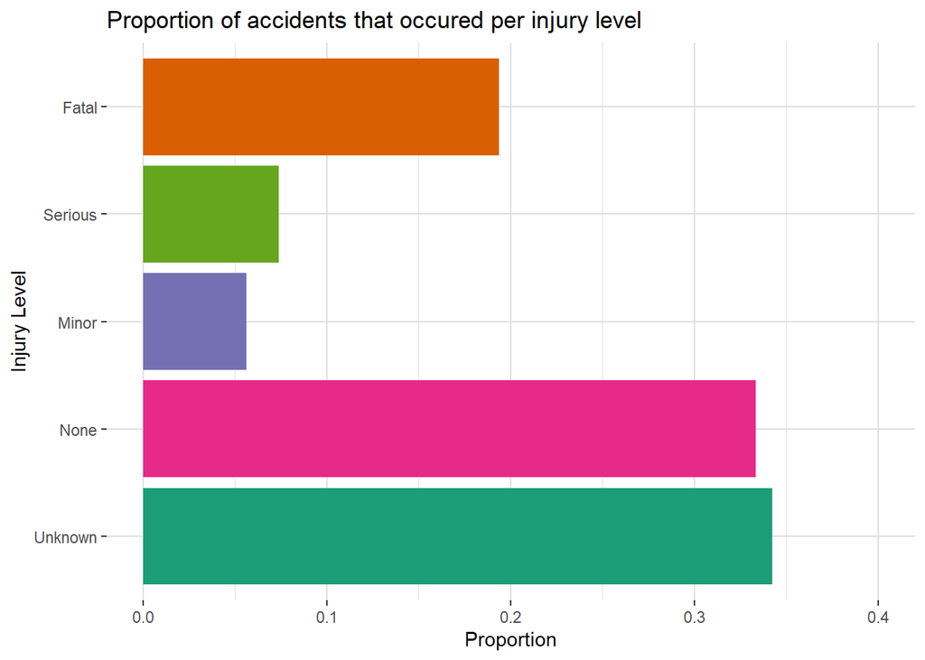

Figure 9

```r
#Proportion of accidents that occurred per injury level
data  %>%
  ggplot(aes(x=factor(InjuryLevel,
                    c("Unknown", "None","Minor", "Serious",  "Fatal")),fill=InjuryLevel)) +
  geom_bar(aes(y = ..count../sum(..count..)),
        stat="count")+
  coord_flip()+
  ylim(0,0.4)+
  labs(title="Proportion of accidents that occured per injury level ", x =
         "Injury Level", y="Proportion")+scale_fill_brewer(palette="Dark2")+
  geom_text(aes(label = scales::percent(..count../sum(..count..), accuracy = 0.1)),
            stat= "count", size=3.5,hjust =-0.2 )+
  my_theme1
```

#### 2.2.2: Fatality by type of aircraft

We investigated fatality further by looking at the proportion of injury level per type of aircraft. Figure 10 shows that helicopters might be more fatal, as there seems to be a large difference in the proportion of fatal injuries between airplanes and helicopters.

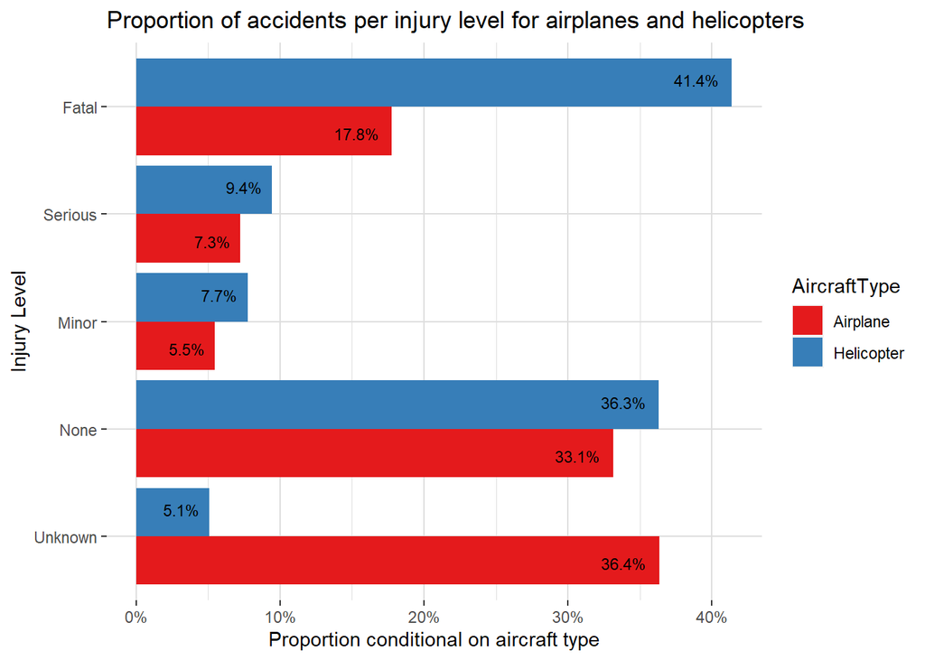

Figure 10

```r
#Bar plot with proportion of accidents per injury level for airplanes and helicopters
data  %>%
  ggplot(aes(x=factor(InjuryLevel,
                    c("Unknown", "None","Minor", "Serious",  "Fatal")),
            group=AircraftType,
            fill=AircraftType
            )) +
  geom_bar(aes(y = ..prop..),
        position = "dodge"
        )+
  coord_flip()+scale_fill_brewer(palette="Set1")+
  labs(title="Proportion of accidents per injury level for airplanes and helicopters",
    x= "Injury Level",
    y="Proportion conditional on aircraft type")+
  scale_y_continuous( #display percentages in the bars
                    labels = scales::percent
                    )+
  geom_text(aes(label = scales::percent(..prop.., accuracy = 0.1), y= ..prop..),
            stat= "count", size=3, position = position_dodge(width = 1),
                        hjust =+1.3 )+my_theme
```

#### 2.2.3: Fatality by flight phase

Since we want to focus more on the differences between fatal and non-fatal accidents, from now on we categorise InjuryLevel as: Fatal, Non-Fatal (None, Minor, Serious combined) and Unknown. Then, we explored fatality in even more depth by looking at during which flight stages the most accidents occur proportionally per aircraft. The plot below, Figure 11, shows that for helicopters, most accidents tend to happen en route for both fatal and non-fatal accidents. Interesting to note is that for airplanes, fatal accidents also happen most often en route. Non-fatal accidents, however, seem to happen most often during the landing phase.

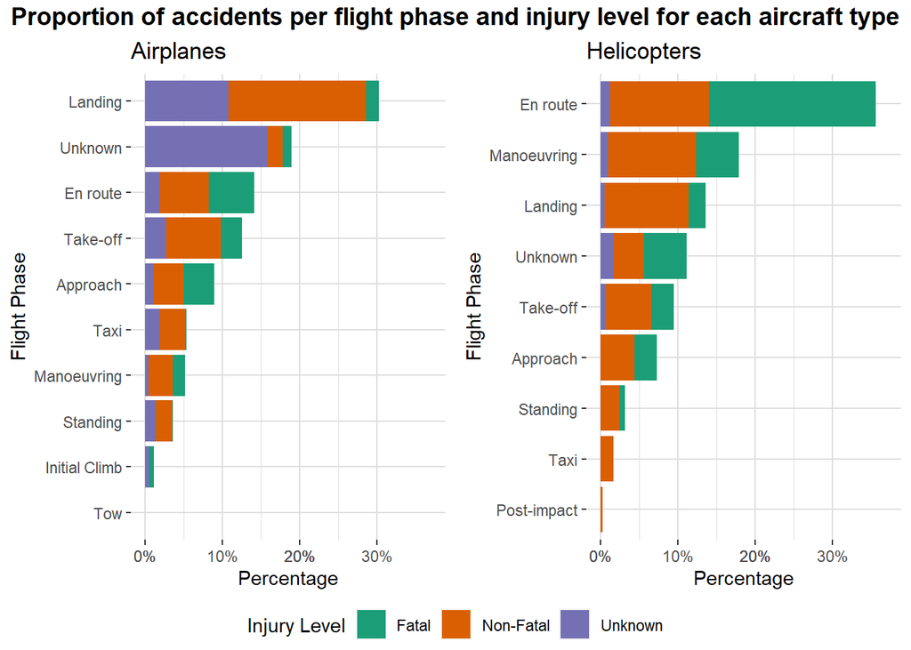

Figure 11

```r
#order of the FlightPhase factor with decreasing frequency of occurrence(for airplanes)
FlightPhase.order.ap<-data %>%subset(AircraftType=="Airplane") %>%
  group_by(FlightPhase) %>%
  summarise(count=n()) %>%
  arrange(.,count) %$%
  FlightPhase

#order of the FlightPhase factor with decreasing frequency of occurrence(for helicopters)
FlightPhase.order.hel<-data %>%subset(AircraftType=="Helicopter") %>%
  group_by(FlightPhase) %>%
  summarise(count=n()) %>%
  arrange(.,count) %$% FlightPhase

#recode InjuryLevel into three categories by putting together levels None,
#Minor and Serious into category Non-Fatal
data<-data %>%
  mutate(InjuryLevel_3 =
        case_when(!InjuryLevel %in% c("Fatal", "Unknown") ~ "Non-Fatal",
                                InjuryLevel=="Unknown" ~ "Unknown",
                                InjuryLevel=="Fatal" ~ "Fatal"
                            ))
#Proportion of accidents that occured in each flight phase categorized by 3-category InjuryLevel
#for airplanes
a<-data %>%subset(AircraftType=="Airplane") %>%
  ggplot( aes(x=factor(FlightPhase, FlightPhase.order.ap), group=InjuryLevel_3,
            fill=InjuryLevel_3)) +
  geom_bar(aes(y = ..count../sum(..count..)),stat="count")+
  coord_flip()+scale_fill_brewer(palette="Dark2")+
  scale_y_continuous(breaks = round(seq(0, 0.45, by = 0.05),1),
                    labels = scales::percent, limits = c(0,0.37))+
  labs(title="Airplanes" ,
    x = "Flight Phase", y="Percentage",
    fill="Injury Level")+
  my_theme
#for helicopters
h<-data %>%subset(AircraftType=="Helicopter") %>%
  ggplot( aes(x=factor(FlightPhase, FlightPhase.order.hel), group=InjuryLevel_3,
            fill=InjuryLevel_3)) +
  geom_bar(aes(y = ..count../sum(..count..)),stat="count")+
  coord_flip()+scale_fill_brewer(palette="Dark2")+
  scale_y_continuous(breaks = round(seq(0, 0.45, by = 0.05),1),
                    labels = scales::percent,limits = c(0,0.37))+
  labs(title="Helicopters" ,
    x = "Flight Phase", y="Percentage",
    fill="Injury Level")+
  my_theme

#put the plot for airplanes and helicoptes together
axh<-ggarrange(a,h, common.legend = TRUE,legend = "bottom")
annotate_figure(axh,
                top=text_grob("Proportion of accidents per flight phase and injury level for each aircraft type",
                            face="bold", size=13.5))
```

#### 2.2.4: Fatality and risk categories

Focusing on the main reasons for the aircraft accidents, we grouped `Risk` variable onto 12 categories and saved under `RiskCat` variable. In the Figure 12 we can see the main reason of non-fatal accidents involving airplanes and helicopters. The main cause of non-fatal accident for airplanes is connected to Runway safety hazards(accidents happening due to poor preparation of the runway), which is directly connected to Landing and Take-off flying phases and is in line with previous part of analysis. For helicopters the the mixture of at least 2 hazards coming from different categories listed in `RiskCat` is the cause of accidents. Figure 13 represents risks involved in fatal accidents. It shows that the most frequent cause of catastrophes among airplanes are connected to Airborne hazards(accidents that happens in the flying phase).An example of this would be a air crush with other flying object.On the other hand, for helicopters causes classified under Airborne and Multiple categories are the major reasons for the accidents. We could conclude that among fatal accidents in general Airborne hazards are the main cause. Also helicopters’ catastrophes more often involve several causes in comparison to the airplanes.

```r
#create a list to order by when plotting fatal cases
Risk_ord_fat<-data %>%filter(InjuryLevel_3=="Fatal") %>%  group_by(RiskCat) %>%
  summarise(count=n()) %>%
  arrange(.,count) %$% RiskCat
#create a list to order by when plotting non fatal cases
Risk_ord<-data %>% filter(InjuryLevel_3=="Non-Fatal") %>%
  group_by(RiskCat) %>%
  summarise(count=n()) %>%
  arrange(.,count) %$% RiskCat
```

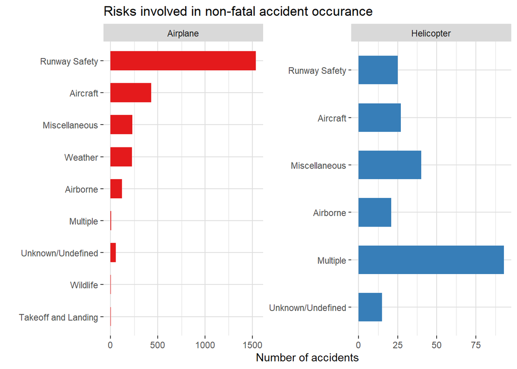

Figure 12

```r
#create plot on causes of non-fatal accidents
data %>%  filter(InjuryLevel_3=="Non-Fatal") %>%
  ggplot(aes(x=factor(RiskCat,Risk_ord),fill=AircraftType))+
  geom_bar(width=0.6)+
  coord_flip()+scale_fill_brewer(palette="Set1")+
  facet_wrap(~AircraftType,scales = "free")+
  my_theme1+
  ggtitle("Risks involved in non-fatal accident occurance")+
  xlab("")+
  ylab("Number of accidents")
```

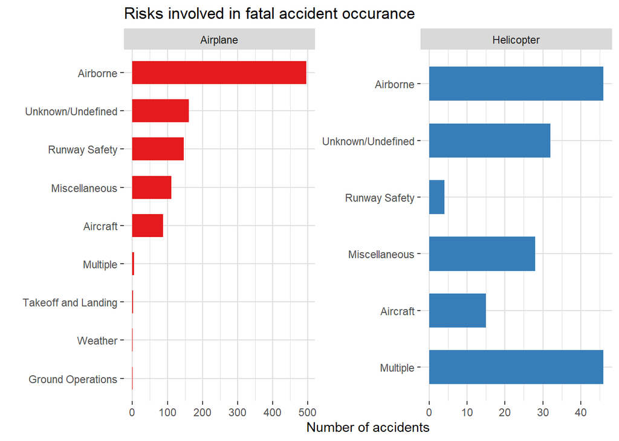

Figure 13

```r
#create plot on causes of fatal accidents
data %>% filter(InjuryLevel_3=="Fatal") %>%
  ggplot(aes(x=factor(RiskCat,Risk_ord_fat),fill=AircraftType))+
  geom_bar(width=0.6)+
  coord_flip()+scale_fill_brewer(palette="Set1")+
  facet_wrap(~AircraftType,scales = "free")+
  my_theme1+
  ggtitle("Risks involved in fatal accident occurance")+xlab("")+
  ylab("Number of accidents")
```